# EPI-Clone Figure 4 - CD34+ Compartment

2024-12-21

This RMarkdown document generates Figure 4, focusing on the CD34+ compartment analysis in the EPI-Clone study. The analysis encompasses clonal analysis with EPI-Clone using the CHOIR method, and visualization of clonal dynamics in relation to patient age and lineage biases.

```r
# corresponds to object on Figshare
S <- readRDS(url('https://figshare.com/ndownloader/files/51354197'))

# Read the list of static consensus CpGs identified across patients
use_cpgs <- scan("static_CpGs_human.csv", what = character())

# we are only looking at patient data if there are more than 1000 cells
patient.age <- S@meta.data %>%
  distinct(sample, age) %>%
  filter(sample %in% names(table(S$sample)[table(S$sample) > 1000])) %>%
  arrange(age)

patients <- patient.age %>% pull(sample)
patient.age <- patient.age %>% pull(age)
names(patient.age) <- patients
```

## scanorama umap (Fig 4B)

We integrated dynamic CpGs and surface proteins using Scanorama to identify cell types and differentiation states within the CD34+ compartment. This integration approach provided robust clustering across individuals despite interindividual differences.

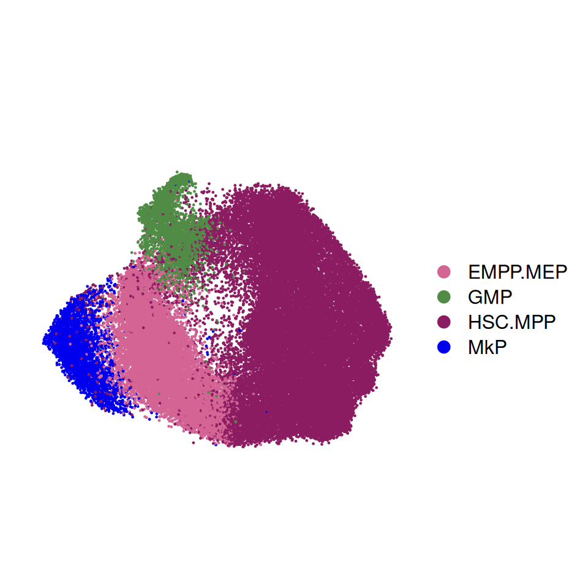

```r
print(DimPlot(S, reduction = "umap", group.by = "celltype", cols = ctcolors) + ggtitle("") + NoAxes() + coord_fixed())
```

## run EPI-Clone using CHOIR

Following the analytical strategy used in mouse data, we made several adjustments for the human cohort. We utilized a consensus set of 94 static CpGs, identified across at least five patients, to enhance EPI-Clone’s performance by providing a robust reference, thereby eliminating the need for individual static CpG identification in future studies. Additionally, we employed CHOIR with FDR adjustment to identify expanded clones, ensuring accurate detection of clonal expansions.

```r
epiclones <- mclapply(patients, function(patient) {
  seurat_subset <- subset(S, sample == patient)

  out <- epiclone(
    seurat_subset,
    trueClone = NULL, batch = "sample", celltype = "celltype", performance.field = "NonHhaI",
    lower.thr.methrate = 0.05, upper.thr.methrate = 0.95, k.bigCloneSelection = 50,
    returnIntermediateSeurat = TRUE, npcs.bigCloneSelection = 30, selected.CpGs = use_cpgs,
    res.Clustering = 2, bigclone.method = "CHOIR", runCHOIR = TRUE
  )

  out[[1]] <- RunTSNE(
    out[[1]], reduction = "clonePCA", dims = 1:30,
    reduction.name = "cloneTSNE", reduction.key = "CLONETSNE_"
  )

  return(out)
}, mc.cores = 7, mc.allow.recursive = TRUE)

names(epiclones) <- patients
```

## B.5 CHIP clone (S8A)

For patient B.5, we visualized CHIP clones using both mutation-based and CHOIR cluster-based UMAPs. The CH mutation was identified de novo.

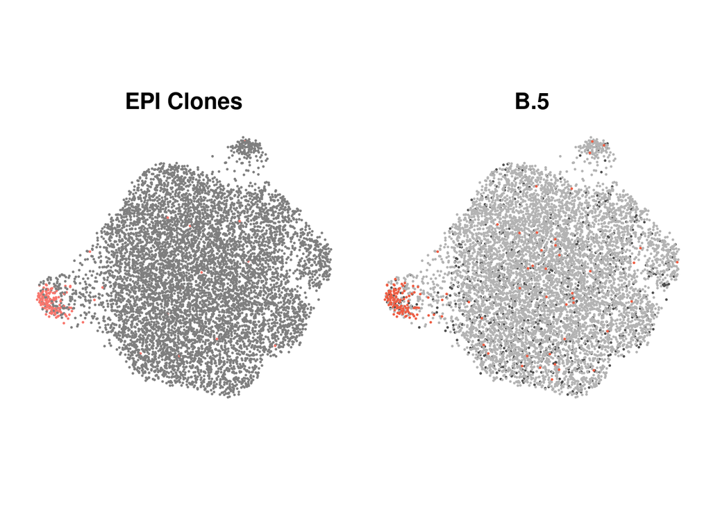

```r
patient <- "B.5"

umap_mutation <- DimPlot(epiclones[[patient]][[1]],
                         reduction = "cloneUMAP",
                         group.by = "mutation",
                         order = rev(names(mutcolors))) +
  NoAxes() +
  coord_fixed() +
  NoLegend() +
  ggtitle(patient) +
  scale_color_manual(values = mutcolors, na.value = "grey80")

umap_clones <- DimPlot(
  epiclones[[patient]][[1]],
  reduction = "cloneUMAP",
  group.by = "CHOIR_clusters_0.05") +
  NoAxes() +
  coord_fixed() +
  NoLegend() +
  ggtitle("EPI Clones") +
  scale_color_manual(values = c("1" = NA, "2" = "#F8766D"))


umap_clones + umap_mutation
```

## clonal size and CHIP clones (EV8B)

This section provides insights into the impact of CHIP, highlighting the connection to clonal expansions.

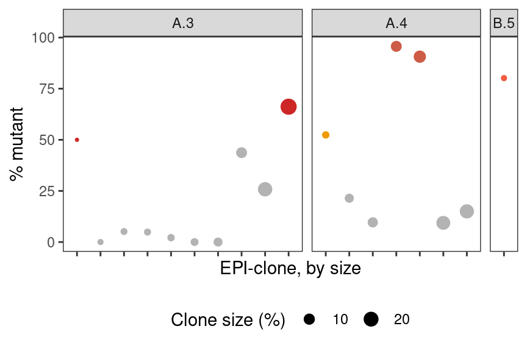

```r
forplot <- bind_rows(lapply(epiclones, function(x) {
  na.omit(data.frame(
    mut = x[[1]]$mutation,
    CHOIR = x[[1]]$CHOIR_clusters_0.05,
    celltype = x[[1]]$celltype,
    patient = unique(x[[1]]$sample)
  ))
}))

patient_totals <- forplot %>%
  group_by(patient) %>%
  dplyr::summarise(total_patient_size = n(), .groups = "drop")

forplot <- forplot %>%
  mutate(mut = if_else(mut == "N/A", NA_character_, mut)) %>%
  group_by(patient, CHOIR) %>%
  dplyr::summarise(
    size = n(),
    perc.wt = mean(mut == "wt", na.rm = TRUE),
    dominant = if (any(!is.na(mut))) names(which.max(table(mut))) else "wt",
    .groups = "drop"
  ) %>%
  left_join(patient_totals, by = "patient") %>%
  mutate(perc = size / total_patient_size)

forplot$key <- with(forplot, paste(patient, CHOIR,sep= "_"))
cluster2dominant <- forplot$dominant; names(cluster2dominant) <- forplot$key
cluster2size <- forplot$size; names(cluster2size) <- forplot$key
cluster2perc <- forplot$perc; names(cluster2perc) <- forplot$key


chip_patients <- c("A.3", "A.4", "B.5")
to_plot <- forplot %>% filter(patient %in% chip_patients) %>%
  dplyr::mutate(key = fct_reorder(key, perc))

plot <- qplot(
  x = key,
  size = 100 * perc,
  y = 100 * (1 - perc.wt),
  data = subset(to_plot, CHOIR != "1"),
  color = dominant
) +
  facet_grid(~patient, space = "free_x", scales = "free_x") +
  theme_bw() +
  theme(
    panel.grid = element_blank(),
    axis.text.x = element_blank(),
    legend.position = "bottom"  # Position the legend at the bottom
  ) +
  ylab("% mutant") +
  xlab("EPI-clone, by size") +
  scale_color_manual(values = mutcolors, guide = "none") +
  scale_size_area(
    name = "Clone size (%)",
    max_size = 4,
    breaks = c(10, 20)
  )

print(plot)
```

## relation between GMP ration and number of expanded clones (Fig 4G)

We assessed the relationship between GMP proportions and the number of expanded clones across patients. This analysis showcases how the proportion of GMP cells correlates with clonal expansions.

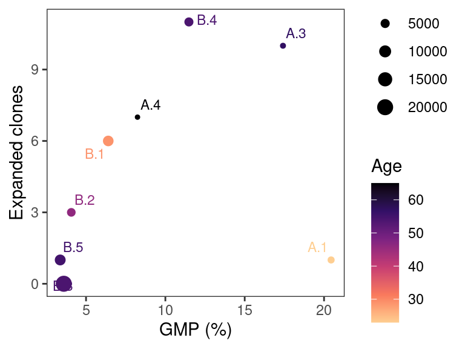

```r
gmp_list <- lapply(patients, function(patient) {
  s.obj <- epiclones[[patient]][[1]]
  ct <- s.obj@meta.data$celltype
  gmp_df <- table(ct) %>% as.data.frame() %>% filter(ct == "GMP")
  proportion <- gmp_df$Freq / sum(table(ct))
  age <- patient.age[[patient]]
  CHOIR.nclones <- length(unique(s.obj$CHOIR_clusters_0.05)) - 1
  ncells <- ncol(s.obj)
  data.frame(sample = patient, proportion, age, CHOIR.nclones, ncells)
})

gmp_df <- bind_rows(gmp_list)

gmp_df <- gmp_df %>%
  mutate(
    GMP_proportion = pmin(pmax(proportion, 0.0001), 0.9999),
    GMP_logit = qlogis(GMP_proportion)
  )

gmp_plot <- ggplot(gmp_df, aes(
  x = GMP_proportion * 100,
  y = CHOIR.nclones,
  label = sample,
  size = ncells,
  color = age
)) +
  geom_point() +
  ggrepel::geom_text_repel(size = 3) +
  scale_color_viridis_c(
    name = "Age",
    option = "magma",
    direction = -1,
    begin = 0,
    end = 0.9
  ) +
  scale_size_area(name = "# cells", max_size = 4) +
  xlab("GMP (%)") +
  ylab("Expanded clones") +
  theme_bw() +
  theme(
    panel.grid = element_blank(),
  )

print(gmp_plot)
```